# Problem Statement - Credit Card Users Churn Prediction

### Gradient Boosting Model with Oversampled data

```python
#Creating pipeline
Model = GradientBoostingClassifier(random_state=1)

#Parameter grid to pass in RandomSearchCV
param_grid = {
    "init": [AdaBoostClassifier(random_state=1),DecisionTreeClassifier(random_state=1)],
    "n_estimators": np.arange(50,110,25),
    "learning_rate": [0.01,0.1,0.05],
    "subsample":[0.7,0.9],
    "max_features":[0.5,0.7,1],
}

# Type of scoring used to compare parameter combinations
scorer = metrics.make_scorer(recall_score)

#Calling RandomizedSearchCV
randomized_cv = RandomizedSearchCV(estimator=Model, param_distributions=param_grid, n_iter=50, scoring=scorer, cv=5, random_state=1, n_jobs = -1)

#Fitting parameters in RandomizedSearchCV
randomized_cv.fit(X_train, y_train)

print("Best parameters are {} with CV score={}:" .format(randomized_cv.best_params_,randomized_cv.best_score_))
```

```
Best parameters are {'subsample': 0.9, 'n_estimators': 100, 'max_features': 0.5, 'learning_rate': 0.1, 'init': AdaBoostClassifier(random_state=1)} with CV score=0.8135112506541079:
```

```python
tuned_gbm1 = GradientBoostingClassifier(
    random_state=1,
    subsample=0.9,
    n_estimators=100,
    max_features=0.5,
    learning_rate=.1,
    init=AdaBoostClassifier(random_state=1),
)
tuned_gbm1.fit(X_train_over, y_train_over)
```

```
GradientBoostingClassifier(init=AdaBoostClassifier(random_state=1),
                           max_features=0.5, random_state=1, subsample=0.9)
```

##### Model's Performance on Training Set

```python
gbm1_train = model_performance_classification_sklearn(tuned_gbm1, X_train_over, y_train_over)
gbm1_train
```

|  | Accuracy | Recall | Precision | F1 |
| --- | --- | --- | --- | --- |
| 0 | 0.975 | 0.978 | 0.972 | 0.975 |

##### Model's Performance on Validation Set

```python
gbm1_val = model_performance_classification_sklearn(tuned_gbm1, X_val, y_val)
gbm1_val
```

|  | Accuracy | Recall | Precision | F1 |
| --- | --- | --- | --- | --- |
| 0 | 0.958 | 0.908 | 0.843 | 0.874 |

### Gradient Boosting Model with Undersampled data

```python
#Creating pipeline
Model = GradientBoostingClassifier(random_state=1)

#Parameter grid to pass in RandomSearchCV
param_grid = {
    "init": [AdaBoostClassifier(random_state=1),DecisionTreeClassifier(random_state=1)],
    "n_estimators": np.arange(50,110,25),
    "learning_rate": [0.01,0.1,0.05],
    "subsample":[0.7,0.9],
    "max_features":[0.5,0.7,1],
}

# Type of scoring used to compare parameter combinations
scorer = metrics.make_scorer(recall_score)

#Calling RandomizedSearchCV
randomized_cv = RandomizedSearchCV(estimator=Model, param_distributions=param_grid, n_iter=50, scoring=scorer, cv=5, random_state=1, n_jobs = -1)

#Fitting parameters in RandomizedSearchCV
randomized_cv.fit(X_train_un,y_train_un)

print("Best parameters are {} with CV score={}:" .format(randomized_cv.best_params_,randomized_cv.best_score_))
```

```
Best parameters are {'subsample': 0.9, 'n_estimators': 100, 'max_features': 0.5, 'learning_rate': 0.1, 'init': AdaBoostClassifier(random_state=1)} with CV score=0.9497959183673469:
```

```python
tuned_gbm2 = GradientBoostingClassifier(
    random_state=1,
    subsample=0.9,
    n_estimators=75,
    max_features=0.7,
    learning_rate=0.1,
    init=AdaBoostClassifier(random_state=1),
)
tuned_gbm2.fit(X_train_un, y_train_un)
```

```
GradientBoostingClassifier(init=AdaBoostClassifier(random_state=1),
                           max_features=0.7, n_estimators=75, random_state=1,
                           subsample=0.9)
```

##### Model's Performance on Training Set

```python
gbm2_train = model_performance_classification_sklearn(tuned_gbm2, X_train_un, y_train_un)
gbm2_train
```

|  | Accuracy | Recall | Precision | F1 |
| --- | --- | --- | --- | --- |
| 0 | 0.971 | 0.977 | 0.965 | 0.971 |

##### Model's Performance on Validation Set

```python
gbm2_val = model_performance_classification_sklearn(tuned_gbm2, X_val, y_val)
gbm2_val
```

|  | Accuracy | Recall | Precision | F1 |
| --- | --- | --- | --- | --- |
| 0 | 0.938 | 0.957 | 0.736 | 0.832 |

### AdaBoost Model with Undersampled data

```python
# defining model
Model = AdaBoostClassifier(random_state=1)

# Parameter grid to pass in RandomSearchCV
param_grid = {
    "n_estimators": np.arange(10, 40, 10),
    "learning_rate": [0.1, 0.01, 0.2, 0.05, 1],
    "estimator": [
        DecisionTreeClassifier(max_depth=1, random_state=1),
        DecisionTreeClassifier(max_depth=2, random_state=1),
        DecisionTreeClassifier(max_depth=3, random_state=1),
    ],
}

# Type of scoring used to compare parameter combinations
scorer = metrics.make_scorer(metrics.recall_score)

#Calling RandomizedSearchCV
randomized_cv = RandomizedSearchCV(estimator=Model, param_distributions=param_grid, n_jobs = -1, n_iter=50, scoring=scorer, cv=5, random_state=1)

#Fitting parameters in RandomizedSearchCV
randomized_cv.fit(X_train_un, y_train_un)

print("Best parameters are {} with CV score={}:" .format(randomized_cv.best_params_,randomized_cv.best_score_))
```

```
Best parameters are {'n_estimators': 30, 'learning_rate': 1, 'estimator': DecisionTreeClassifier(max_depth=2, random_state=1)} with CV score=0.9375039246467818:
```

```python
tuned_adb = AdaBoostClassifier(
    random_state=1,
    n_estimators=30,
    learning_rate=1,
    estimator=DecisionTreeClassifier(max_depth=2, random_state=1),
)
tuned_adb.fit(X_train_un, y_train_un)
```

```
AdaBoostClassifier(estimator=DecisionTreeClassifier(max_depth=2,
                                                    random_state=1),
                   learning_rate=1, n_estimators=30, random_state=1)
```

##### Model's Performance on Training Set

```python
adb_train = model_performance_classification_sklearn(tuned_adb, X_train_un, y_train_un)
adb_train
```

|  | Accuracy | Recall | Precision | F1 |
| --- | --- | --- | --- | --- |
| 0 | 0.953 | 0.956 | 0.951 | 0.954 |

##### Model's Performance on Validation Set

```python
adb_val = model_performance_classification_sklearn(tuned_adb, X_val, y_val)
adb_val
```

|  | Accuracy | Recall | Precision | F1 |
| --- | --- | --- | --- | --- |
| 0 | 0.930 | 0.951 | 0.713 | 0.815 |

### **Model Performance Comparison and Final Model Selection**

#### **Training Performance Comparison**

```python
models_train_comp_df = pd.concat(
    [
        gbm0_train.T,
        gbm1_train.T,
        gbm2_train.T,
        adb_train.T,
    ],
    axis=1,
)
models_train_comp_df.columns = [
    "GB_trained_with_Original_Data",
    "GB_trained_with_Oversampled_Data",
    "GB_trained_with_Undersampled_Data",
    "AB_trained_with_Undersampled_Data",
]
print("Training performance comparison:")
models_train_comp_df
```

```
Training performance comparison:
```

|  | GB_trained_with_Original_Data | GB_trained_with_Oversampled_Data | GB_trained_with_Undersampled_Data | AB_trained_with_Undersampled_Data |
| --- | --- | --- | --- | --- |
| Accuracy | 0.949 | 0.975 | 0.971 | 0.953 |
| Recall | 0.983 | 0.978 | 0.977 | 0.956 |
| Precision | 0.765 | 0.972 | 0.965 | 0.951 |
| F1 | 0.860 | 0.975 | 0.971 | 0.954 |

#### **Validation Performance Comparison**

```python
models_train_comp_df = pd.concat(
    [
        gbm0_val.T,
        gbm1_val.T,
        gbm2_val.T,
        adb_val.T], axis=1,
)
models_train_comp_df.columns = [
    "GB_trained_with_Original_Data",
    "GB_trained_with_Oversampled_Data",
    "GB_trained_with_Undersampled_Data",
    "AB_trained_with_Undersampled_Data",
]
print("Validation performance comparison:")
models_train_comp_df
```

```
Validation performance comparison:
```

|  | GB_trained_with_Original_Data | GB_trained_with_Oversampled_Data | GB_trained_with_Undersampled_Data | AB_trained_with_Undersampled_Data |
| --- | --- | --- | --- | --- |
| Accuracy | 0.939 | 0.958 | 0.938 | 0.930 |
| Recall | 0.957 | 0.908 | 0.957 | 0.951 |
| Precision | 0.741 | 0.843 | 0.736 | 0.713 |
| F1 | 0.835 | 0.874 | 0.832 | 0.815 |

### Test Set Final Performance

```python
gbm0_test = model_performance_classification_sklearn(tuned_gbm0, X_test, y_test)
gbm0_test
```

|  | Accuracy | Recall | Precision | F1 |
| --- | --- | --- | --- | --- |
| 0 | 0.936 | 0.972 | 0.725 | 0.830 |

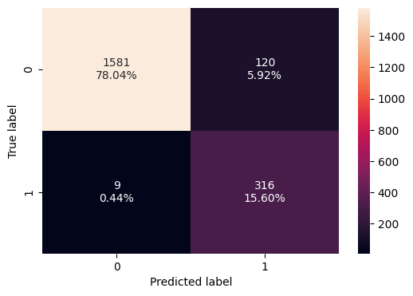

```python
confusion_matrix_sklearn(tuned_gbm0, X_test, y_test)
```

#### Ada Boost (AB) Trained with Undersampled Data

```python
ada_test = model_performance_classification_sklearn(tuned_adb, X_test, y_test)
ada_test
```

|  | Accuracy | Recall | Precision | F1 |
| --- | --- | --- | --- | --- |
| 0 | 0.922 | 0.951 | 0.685 | 0.796 |

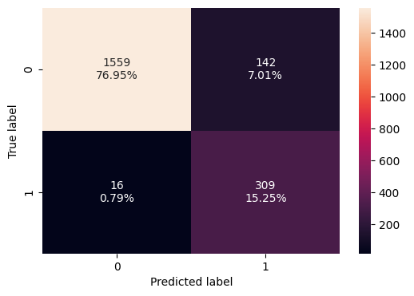

```python
confusion_matrix_sklearn(tuned_adb, X_test, y_test)
```

### Feature Importance

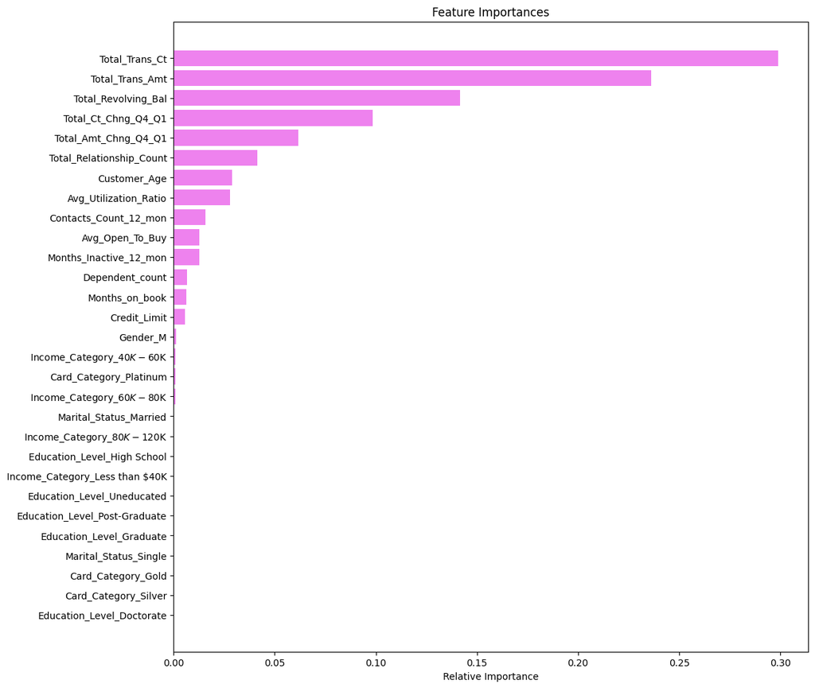

```python
feature_names = X_train.columns
importances = tuned_gbm0.feature_importances_
indices = np.argsort(importances)

plt.figure(figsize=(12, 12))
plt.title("Feature Importances")
plt.barh(range(len(indices)), importances[indices], color="violet", align="center")
plt.yticks(range(len(indices)), [feature_names[i] for i in indices])
plt.xlabel("Relative Importance")
plt.show()
```

##### **Observations:**

- The most significant features for making predictions were **Total_Trans_Ct, Total_Trans_Amt, Total_Revolving_Bal, Total_Ct_Chng_Q4_Q1,** and **Total_Amt_Chng_Q4_Q1**.

## **Actionable Insights & Recommendations**

### **Actionable Insights:**

By analyzing the model, we can determine key factors influencing credit card attrition:

1. **Primary Indicators:**
   - The strongest predictors of whether a customer retains their credit card include **current usage patterns, transaction amounts, and revolving balances.**
2. **Secondary Indicators:**
   - **Changes in transaction behavior** (both in terms of transaction count and transaction amount) play a significant role in predicting attrition.
3. **Additional Factors:**
   - **Credit utilization rate** and **frequency of customer interactions with the bank** (such as support calls, branch visits, or digital engagement) also contribute to predicting attrition.

### **Recommendations**

Considering risk management for the bank, the following strategies may help reduce credit card attrition:

1. **Increase Customer Engagement & Usage:**
   - Offer **balance transfer incentives** to increase utilization and revolving balances, key factors affecting retention.
   - Provide **cashback rewards** or personalized incentives for frequent card usage.
   - Partner with online payment providers like **PayPal or SHOP** to encourage more transactions.
2. **Expand Cross-Selling Opportunities:**
   - Encourage customers to adopt additional financial products (e.g., **personal loans, savings accounts, or investment plans**) to strengthen their relationship with the bank.
3. **Leverage Flexible Payment Options:**
   - Introduce **"Pay in 4" or installment payment features** to encourage higher spending while maintaining affordability for customers.
4. **Further Analysis Considerations:**
   - **Macroeconomic factors** such as **interest rate changes and economic conditions** were not included in this study but may significantly impact customer behavior. Future analyses should explore these aspects for deeper insights.
   - The study does not investigate **customer sentiment or reasons** for discontinuing credit cards. Additional qualitative research (e.g., customer surveys or feedback analysis) could provide valuable insights.